# Ch9_Probability

Steve Newns

October 6, 2017

### 9.4 - The Binomial Distribution’

- **d form** = **density** = probability of obtaining a given input value
- **p form** = **cumulative probability** = probability of obtaining an outcome equal to or smaller than a given q
- **q form** = **quantiles** = calculates quantile/percentile based on given probability value p of obtaining a given input value (i.e value for which there is a p% of obtaining an outcome lower than the resulting value)
- **r form** = **random # generator** = generate random outcomes from a distribution

The probability of getting *exactly 4* fives when rolling a fair 6-sided dice 20 times w/ **dbinom*

```r
dbinom(x = 4, size = 20, prob = 1/6)
```

```
## [1] 0.2022036
```

Get the probability of rolling *4 or less* fives on 20 twenty rolls of 6-sided dice w/ **pbinom**

```r
pbinom(4, 20, 1/6)
```

```
## [1] 0.7687492
```

This is actually the 76.9th percentile of this binomial distribution.

Find value of x that gives 75th percentile of the binomial distribution for rolling a 6-sided die 20 times w/ **qbinom**

```r
qbinom(.75, 20, 1/6)
```

```
## [1] 4
```

This appears to be telling us the 75th percentile of the binomial distribution is = 4, even though we saw from **pbinom()** that 4 is *actually* the 76.9th percentile.

Check the probability of rolling a 3 or less in 20 rolls.

```r
pbinom(3, size = 20, prob = 1/6) #56.65%
```

```
## [1] 0.5665456
```

So there’s a 56.7% chance of rolling 3 or fewer fives + a 76.9% chance of rolling 4 or fewer fives.

So there’s a sense in which *the 75th percentile should lie “in between” 3 + 4 fives*, which is impossible. We can’t roll 20 dice + get 3.9 of them come up as fives.

To handle this issue, we can:

- report an **interpolated** (in-between) value, suchas 3.9
- round down to 3 or up to 4
- qbinom rounds up if we ask for a percentile that *doesn’t actually exist* (i.e. our 75th percentile is not a whole #)

But, this issue only occurs w/ **discrete distributions**, such as the binomial, while the normal, t, chi.sq, and F distributions are all **continuous**.

“Simulate” dice experiment 100 times to generate random outcomes from the binomial distribution w/ the **Mersenne twister method**.

```r
rbinom(n = 100, size = 20, prob = 1/6)
```

```
##   [1] 4 3 4 1 3 2 3 3 3 3 4 5 6 3 6 4 4 5 4 4 5 3 3 7 3 0 2 6 3 4 3 6 6 4 2
##  [36] 4 4 4 3 5 4 4 3 3 5 3 2 2 3 4 1 5 3 4 3 2 1 3 4 3 0 4 3 6 1 2 2 3 5 5
##  [71] 5 3 4 0 5 3 2 3 5 6 2 1 3 2 1 3 3 4 2 2 1 3 2 4 5 2 4 2 3 4
```

## Normal Distribution

Calculate density of x = 1 (probability of obtaining this value) for a normally-distributed variable w/ mean = 1 + SD = 0.1

```r
dnorm(1, mean = 1, sd = 0.1)
```

```
## [1] 3.989423
```

The normal distribution is continuous, whereas the binomial is discrete (possible to get 3 fives or 4 fives, but impossible to get 3.9 fives).

In practice, the normal distribution is so handy people tend to use it even when a variable isn’t actually continuous. As long as there are enough categories, it’s pretty standard practice to use the normal distribution as an approximation.

Now, generate 1000 normally-distributed observations (values normal distribution of 1K values) + view the histogram.

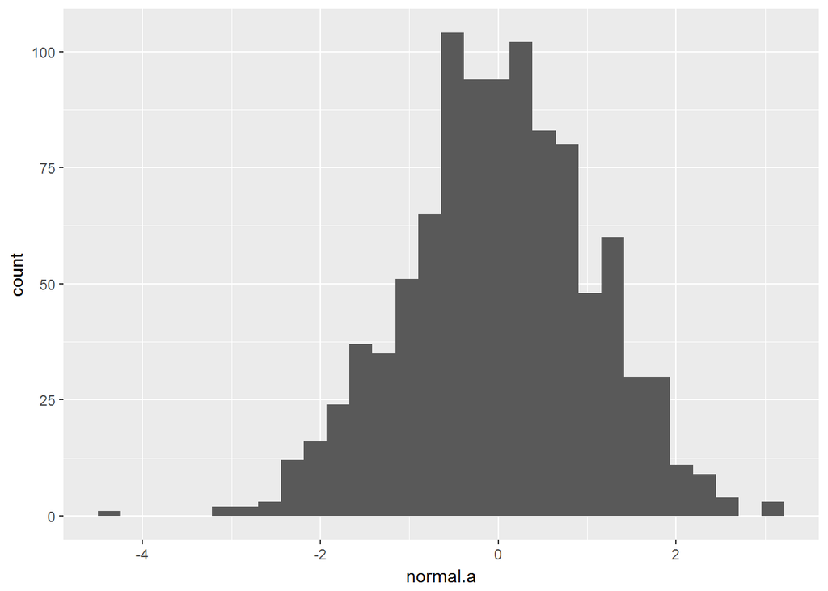

```r
normal.a <- rnorm(1000, mean = 0, sd = 1)

library(ggplot2)
ggplot() +
  geom_histogram(aes(normal.a))
```

The **t distribution** = a continuous distribution that looks very similar to a normal distribution, but w/ heavier tails (extend further outward). It tends to arise in situations where you think the data actually follow a normal distribution, but you **don’t know the mean or standard deviation.**

**Chi.sq distributions** turn up all over the place when doing categorical data analysis

If we have a bunch of variables that’re normally distributed + we square their values + then add them up (**sum of squares**), this sum has a Chi.sq distribution w/ “k” dF, which has k normally-distributed populations/variables, squared + added up.

If we want a Chi.sq distribution w/ dF = 3, we’ll need 3 sets of normally-distributed observations

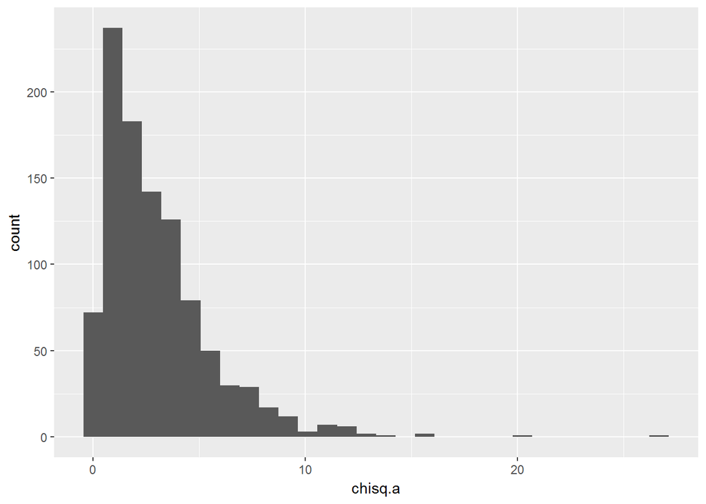

```r
chisq.a <- rchisq(1000, df = 3)
ggplot() +
  geom_histogram(aes(chisq.a))
```

Another way to get a chi-squared distributino is via the **sum of squares**

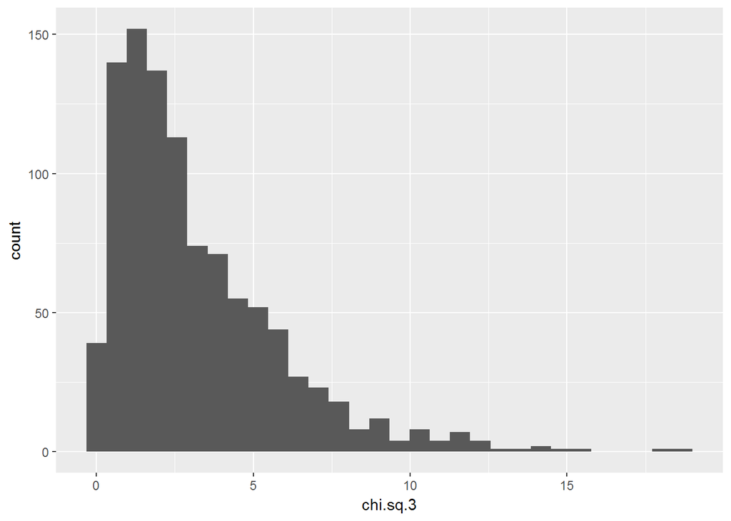

```r
# square values of 3 distributions and sum
normal.a <- rnorm(1000)
normal.b <- rnorm(1000)
normal.c <- rnorm(1000)
chi.sq.3 <- (normal.a)^2 + (normal.b)^2 + (normal.c)^2
ggplot() +
  geom_histogram(aes(chi.sq.3))
```

We can create **t-distributions** from a *scaled chi-squared* distribution

- t distribution = related to the normal distribution but *the SD is unknown*

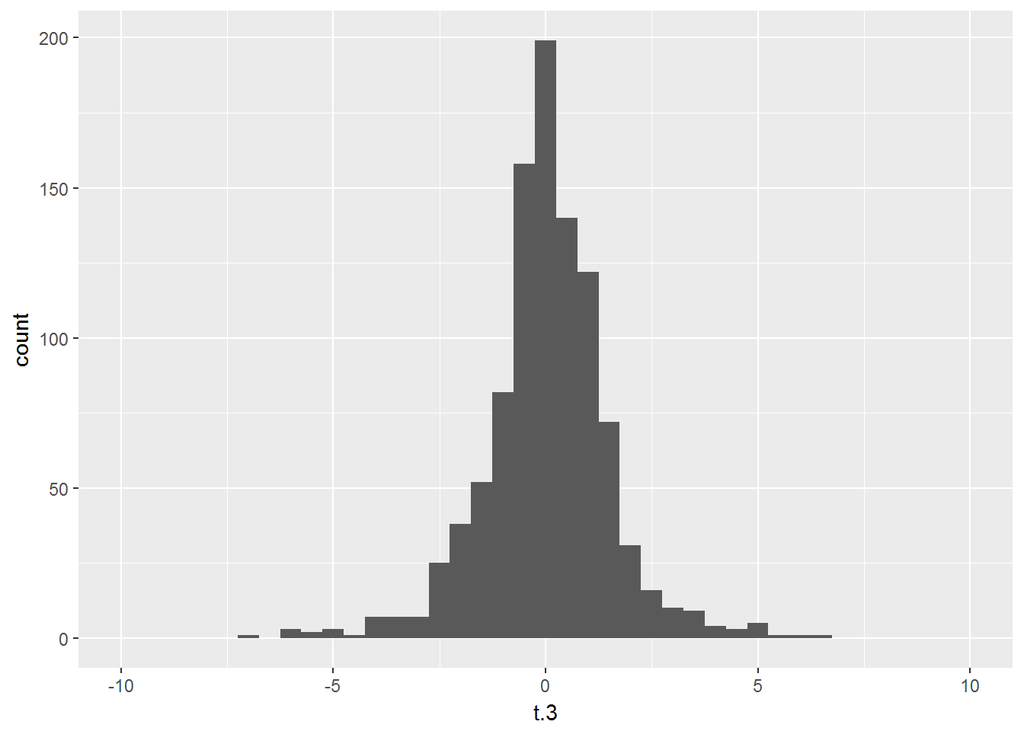

```r
scaled.chisq.3 <- chi.sq.3/3

normal.d <- rnorm(1000)

t.3 <- normal.d / sqrt(scaled.chisq.3)

ggplot() +
  geom_histogram(aes(t.3), binwidth = .5) +
  coord_cartesian(xlim =  c(-10,10))
```

Now to create an F-distribution by generating 2 chi-square variables w/ dF = 3 + dF = 20 via ratio of 2 scaled chi-sq distributions

- F-distribution = typically when comparing 2 different sums of squares

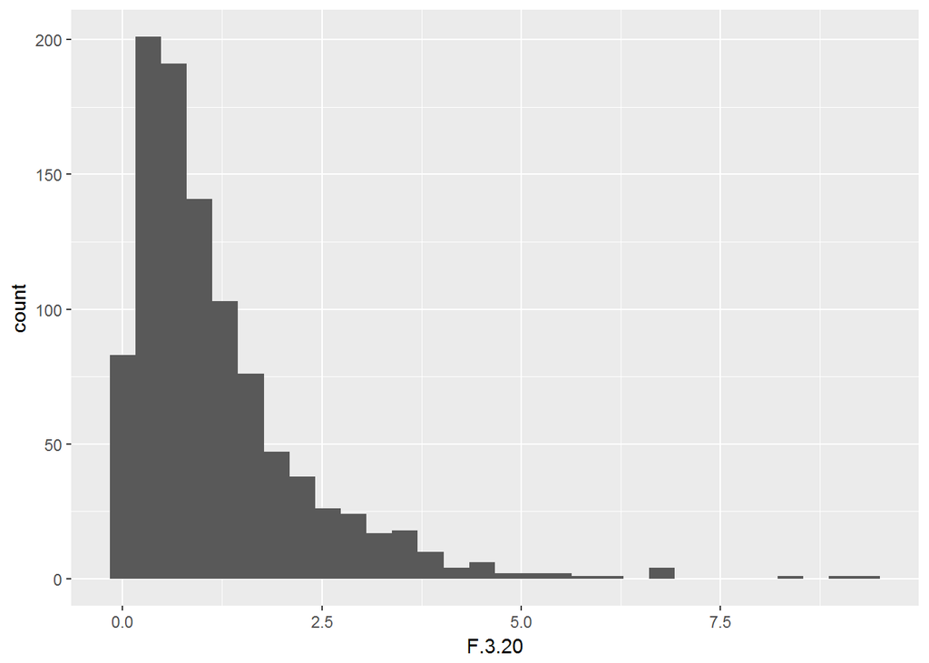

```r
chi.sq.20 <- rchisq( 1000, 20)
scaled.chi.sq.20 <- chi.sq.20 / 20
F.3.20 <- scaled.chisq.3 / scaled.chi.sq.20
ggplot() + geom_histogram(aes(F.3.20))
```